# ANALYZE_casestudy_01_cyclisticbikeshare_2019to2020

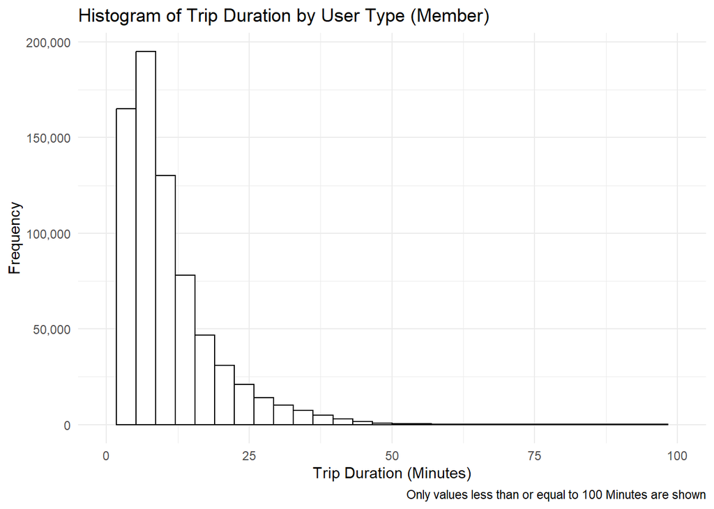

```r
# The number of observations between 100 (exclusive) and 200 (inclusive) is 431.
var_big_member <- data_chart_combined_member %>%
  filter(tripduration_min <= 200 & tripduration_min > 100) %>%
  nrow()

# Only minutes less than or equal to 100 are graphed
data_chart_combined_member_less100 <- data_chart_combined_member %>%
  filter(tripduration_min <= 100)

# Creating a graph below 100
ggplot(data = data_chart_combined_member_less100, mapping = aes(x = tripduration_min)) +
  geom_histogram(fill = "white", color = "black") +
  labs(title = "Histogram of Trip Duration by User Type (Member)",
       x = "Trip Duration (Minutes)",
       y = "Frequency",
       caption = "Only values less than or equal to 100 Minutes are shown") +
  xlim(0, 100) +
  scale_y_continuous(labels = comma) +
  theme_minimal()
```

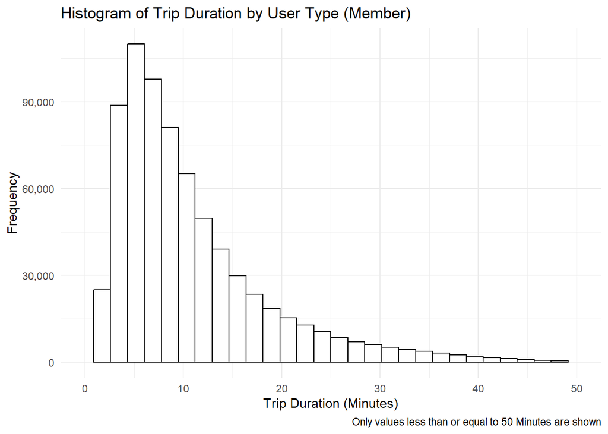

```r
# The number of observations between 50 (exclusive) and 100 (inclusive) is 2415.
var_medium_member <- data_chart_combined_member %>%
  filter(tripduration_min <= 100 & tripduration_min > 50) %>%
  nrow()

# Only minutes less than or equal to 50 are graphed
data_chart_combined_member_less50 <- data_chart_combined_member %>%
  filter(tripduration_min <= 50)

# Creating a graph below 50
ggplot(data = data_chart_combined_member_less50, mapping = aes(x = tripduration_min)) +
  geom_histogram(fill = "white", color = "black") +
  labs(title = "Histogram of Trip Duration by User Type (Member)",
       x = "Trip Duration (Minutes)",
       y = "Frequency",
       caption = "Only values less than or equal to 50 Minutes are shown") +
  xlim(0, 50) +
  scale_y_continuous(labels = comma) +
  theme_minimal()
```

- For members most of the trips last less than 30 minutes.

- Highest bin width occurs at 5 minute range.
- This can be hypothesized as Members using the bikes for commute purposes, which would be validated upon checking the ride usage time.

### Causal user’s trip duration is analyzed

```r
# 'tripduration_min' is explored
data_chart_combined_casual <- data_combined_pos %>%
  filter(usertype == "Casual")

# how many outlier values are in tripduration_min? (Assuming Gaussian distribution, the definition of "any value above or below 3 standard deviations from the mean" is used as the definition of outlier. Only upper bound is checked since the dataset is a right-tailed distribution.)
cal_tripduration_stats_casual <- data_chart_combined_casual %>%
  summarize(
    mean_trip = mean(tripduration_min, na.rm = TRUE),
    sd_trip = sd(tripduration_min, na.rm = TRUE)
  )

var_upper_bound_casual <- cal_tripduration_stats_casual$mean_trip + 3 * cal_tripduration_stats_casual$sd_trip

var_outlier_casual <- data_chart_combined_casual %>%
  filter(tripduration_min > var_upper_bound) %>%
  nrow()

# The number of ouliers are 491
var_outlier_casual
```

```
## [1] 491
```

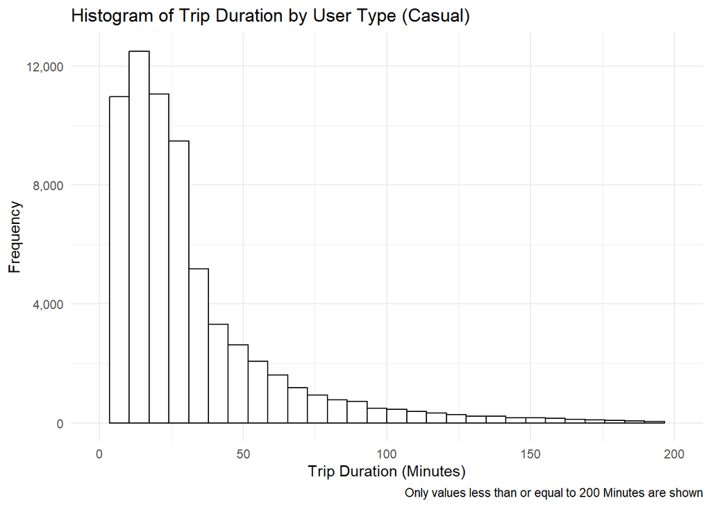

```r
# The number of observations between 200 (inclusive) and var_upper_bound is 1086.
var_large_casual <- data_chart_combined_casual %>%
  filter(tripduration_min <= var_upper_bound_casual & tripduration_min > 200) %>%
  nrow()

# Only minutes less than or equal to 200 are graphed
data_chart_combined_casual_less200 <- data_chart_combined_casual %>%
  filter(tripduration_min <= 200)

# Creating a graph below 200
ggplot(data = data_chart_combined_casual_less200, mapping = aes(x = tripduration_min)) +
  geom_histogram(fill = "white", color = "black") +
  labs(title = "Histogram of Trip Duration by User Type (Casual)",
       x = "Trip Duration (Minutes)",
       y = "Frequency",
       caption = "Only values less than or equal to 200 Minutes are shown") +
  xlim(0, 200) +
  scale_y_continuous(labels = comma) +
  theme_minimal()
```

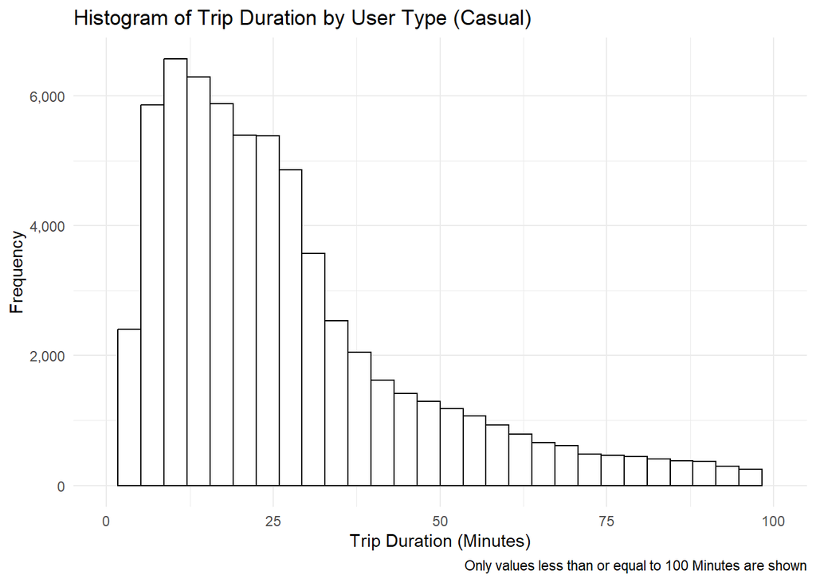

```r
# Only minutes less than or equal to 100 are graphed
data_chart_combined_casual_less100 <- data_chart_combined_casual %>%
  filter(tripduration_min <= 100)

# Creating a graph below 100
ggplot(data = data_chart_combined_casual_less100, mapping = aes(x = tripduration_min)) +
  geom_histogram(fill = "white", color = "black") +
  labs(title = "Histogram of Trip Duration by User Type (Casual)",
       x = "Trip Duration (Minutes)",
       y = "Frequency",
       caption = "Only values less than or equal to 100 Minutes are shown") +
  xlim(0, 100) +
  scale_y_continuous(labels = comma) +
  theme_minimal()
```

- Also, the mean and the SD (standard deviation) of the tripduration for the Casual usertype is far larger than that for the Member usertype.

```r
# What is the general descriptive statistics of the tripduration for the two different usertypes (Casual vs. Members)?
cal_tripduration_stat <- data_combined_pos %>%
  group_by(usertype) %>%
  summarize(
    mean = mean(tripduration_min),
    median = median(tripduration_min),
    sd = sd(tripduration_min),
    min = min(tripduration_min),
    max = max(tripduration_min)
            )

cal_tripduration_stat
```

```
## # A tibble: 2 × 6
##   usertype  mean median    sd    min     max
##   <chr>    <dbl>  <dbl> <dbl>  <dbl>   <dbl>
## 1 Casual    85.0  22.0  1624. 0      177200.
## 2 Member    13.3   8.47  273. 0.0167 101607.
```

- This suggests that Casual usertype has varying use cases. And some are using the service disproportionately.

### Analyze the start_time and end_time of the casual users

```r
cal_time_hour_casual <- data_chart_combined_casual %>%
  mutate(hour = hour(start_time)) %>%
  group_by(hour) %>%
  summarise(trip_count = n()) %>%
  arrange(desc(trip_count))

cal_time_hour_casual
```

```
## # A tibble: 24 × 2
##     hour trip_count
##    <int>      <int>
##  1    15       7990
##  2    14       7919
##  3    16       7665
##  4    13       7491
##  5    17       7004
##  6    12       6040
##  7    11       4813
##  8    18       4272
##  9    10       3820
## 10     9       2613
## # ℹ 14 more rows
```

- It appears that Sunlight could be the main predictor of bike usage.
  - Most usage occurs from 13 to 17.
  - It can slightly be expanded to include 11 to 18.

### Analyze the start_day and end_day of the casual users

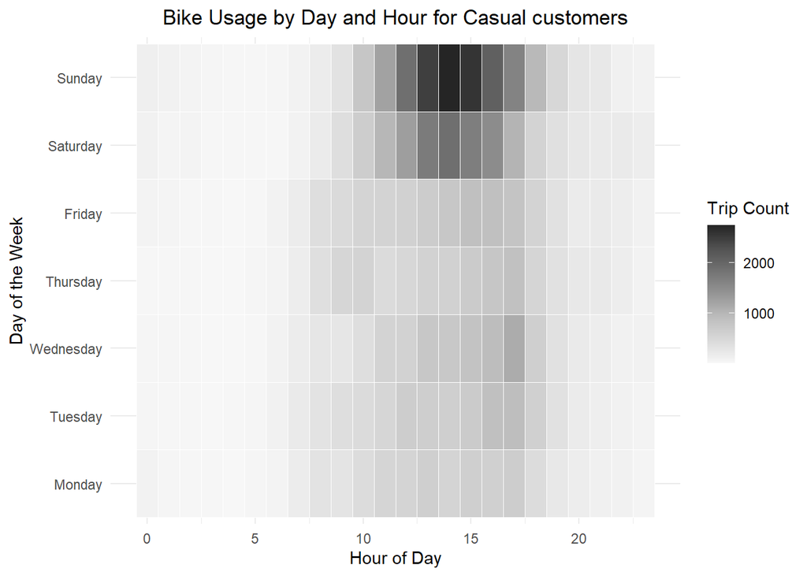

```r
# Analyze hour-start day combination
cal_time_hour_startday_casual <- data_chart_combined_casual %>%
  mutate(
    day = wday(start_time, label = TRUE, abbr = FALSE),
    hour = hour(start_time)
  ) %>%
  group_by(day, hour) %>%
  summarise(trip_count = n(), .groups = "drop") %>%
  arrange(desc(trip_count))

cal_time_hour_startday_casual <-  cal_time_hour_startday_casual %>%
  mutate(day = factor(day, levels = c("Monday", "Tuesday", "Wednesday", "Thursday", "Friday", "Saturday", "Sunday")))

ggplot(cal_time_hour_startday_casual, aes(x = hour, y = day, fill = trip_count)) +
  geom_tile(color = "white") +
  scale_fill_distiller(palette = "Greys", direction = 1) +
  labs(title = "Bike Usage by Day and Hour for Casual customers",
       x = "Hour of Day",
       y = "Day of the Week",
       fill = "Trip Count") +
  theme_minimal() +
  theme(
    plot.title = element_text(hjust = 0.5)
  )
```

```r
# Visualizing hour-start day combination
cal_time_hour_startday_casual
```

```
## # A tibble: 168 × 3
##    day       hour trip_count
##    <ord>    <int>      <int>
##  1 Sunday      14       2752
##  2 Sunday      15       2597
##  3 Sunday      13       2477
##  4 Sunday      16       2104
##  5 Saturday    14       1897
##  6 Sunday      12       1885
##  7 Saturday    13       1737
##  8 Saturday    15       1688
##  9 Sunday      17       1628
## 10 Saturday    16       1504
## # ℹ 158 more rows
```

- Sunday and Saturday seems to have the highest usage.
- From this fact, we can infer that the usage is mostly for leisure (picnic) instead of commute.
- Let’s further analyze location data to check which spots might be most suitable for advertisements.

### Analyze the from_station_id, from_station_name, to_station_id, and to_station_name of the casual users

```r
# Explore popular starting station for the Casual usertype
cal_loc_popstart_casual <- data_chart_combined_casual %>%
  group_by(from_station_id, from_station_name) %>%
  summarise(trip_count = n(), .groups = "drop") %>%
  arrange(desc(trip_count)) %>%
  slice_head(n = 10)

cal_loc_popstart_casual
```

```
## # A tibble: 10 × 3
##    from_station_id from_station_name            trip_count
##    <chr>           <chr>                             <int>
##  1 675             HQ QR                              3649
##  2 35              Streeter Dr & Grand Ave            2749
##  3 76              Lake Shore Dr & Monroe St          2732
##  4 3               Shedd Aquarium                     1832
##  5 90              Millennium Park                    1406
##  6 85              Michigan Ave & Oak St              1017
##  7 43              Michigan Ave & Washington St        839
##  8 6               Dusable Harbor                      832
##  9 341             Adler Planetarium                   827
## 10 177             Theater on the Lake                 795
```

```r
# Compare the popular starting station for the Member usertype
cal_loc_popstart_member <- data_chart_combined_member %>%
  group_by(from_station_id, from_station_name) %>%
  summarise(trip_count = n(), .groups = "drop") %>%
  arrange(desc(trip_count)) %>%
  slice_head(n = 10)

cal_loc_popstart_member
```

```
## # A tibble: 10 × 3
##    from_station_id from_station_name            trip_count
##    <chr>           <chr>                             <int>
##  1 192             Canal St & Adams St               13799
##  2 91              Clinton St & Washington Blvd      13434
##  3 77              Clinton St & Madison St           12891
##  4 133             Kingsbury St & Kinzie St           8720
##  5 195             Columbus Dr & Randolph St          8515
##  6 174             Canal St & Madison St              7957
##  7 287             Franklin St & Monroe St            7010
##  8 43              Michigan Ave & Washington St       6686
##  9 48              Larrabee St & Kingsbury St         6467
## 10 66              Clinton St & Lake St               6439
```

```r
# Explore popular ending station for the Casual usertype
cal_loc_popend_casual <- data_chart_combined_casual %>%
  group_by(to_station_id, to_station_name) %>%
  summarise(trip_count = n(), .groups = "drop") %>%
  arrange(desc(trip_count)) %>%
  slice_head(n = 10)

cal_loc_popend_casual
```

```
## # A tibble: 10 × 3
##    to_station_id to_station_name              trip_count
##    <chr>         <chr>                             <int>
##  1 35            Streeter Dr & Grand Ave            3790
##  2 675           HQ QR                              3648
##  3 76            Lake Shore Dr & Monroe St          2160
##  4 90            Millennium Park                    1934
##  5 3             Shedd Aquarium                     1461
##  6 85            Michigan Ave & Oak St              1185
##  7 177           Theater on the Lake                1080
##  8 43            Michigan Ave & Washington St        965
##  9 268           Lake Shore Dr & North Blvd          771
## 10 199           Wabash Ave & Grand Ave              745
```

```r
# Compare the popular ending station for the Member usertype
cal_loc_popend_member <- data_chart_combined_member %>%
  group_by(to_station_id, to_station_name) %>%
  summarise(trip_count = n(), .groups = "drop") %>%
  arrange(desc(trip_count)) %>%
  slice_head(n = 10)

cal_loc_popend_member
```

```
## # A tibble: 10 × 3
##    to_station_id to_station_name              trip_count
##    <chr>         <chr>                             <int>
##  1 192           Canal St & Adams St               14807
##  2 91            Clinton St & Washington Blvd      14580
##  3 77            Clinton St & Madison St           13310
##  4 133           Kingsbury St & Kinzie St           8798
##  5 174           Canal St & Madison St              8265
##  6 43            Michigan Ave & Washington St       7674
##  7 66            Clinton St & Lake St               6709
##  8 287           Franklin St & Monroe St            6315
##  9 81            Daley Center Plaza                 6300
## 10 283           LaSalle St & Jackson Blvd          6238
```

```r
# Check for any row that started out as HQ QR but ended up elsewhere
var_starthq_endnothq <- data_chart_combined_casual %>%
  filter(from_station_id == 675 & to_station_id != 675)

var_starthq_endnothq
```

```
##            start_time            end_time tripduration tripduration_min
## 1 2020-02-27 18:17:19 2020-02-27 18:18:04           45             0.75
##   start_day  end_day from_station_id from_station_name to_station_id
## 1  Thursday Thursday             675             HQ QR           671
##            to_station_name usertype source
## 1 HUBBARD ST BIKE CHECKING   Casual 2020Q1
```

```r
var_hubbard_bikecheck <- data_combined_pos %>%
  filter(from_station_id == 671 | to_station_id == 671)

var_hubbard_bikecheck
```

```
##             start_time            end_time tripduration tripduration_min
## 1  2020-01-02 12:10:22 2020-01-03 13:47:38        92236      1537.266667
## 2  2020-01-10 15:01:02 2020-01-11 20:11:27       105025      1750.416667
## 3  2020-01-10 09:28:31 2020-01-10 09:46:08         1057        17.616667
## 4  2020-01-30 10:22:23 2020-01-30 10:49:52         1649        27.483333
## 5  2020-01-30 16:59:14 2020-01-30 17:26:42         1648        27.466667
## 6  2020-01-28 23:13:54 2020-02-07 12:43:14       826160     13769.333333
## 7  2020-01-20 15:52:23 2020-02-15 14:32:06      2241583     37359.716667
## 8  2020-01-20 15:52:38 2020-02-15 14:33:20      2241642     37360.700000
## 9  2020-02-23 22:22:18 2020-02-24 11:04:25        45727       762.116667
## 10 2020-02-28 08:26:42 2020-02-28 08:52:30         1548        25.800000
## 11 2020-02-21 17:09:01 2020-02-21 17:35:25         1584        26.400000
## 12 2020-02-08 08:27:53 2020-02-08 08:53:31         1538        25.633333
## 13 2020-02-21 08:31:31 2020-02-21 09:00:08         1717        28.616667
## 14 2020-02-22 13:21:23 2020-02-22 13:25:55          272         4.533333
```

[output cut: 90 more lines]

```r
# Check for other potential repair center station names
temp_unique_from_station <- data_combined_pos %>%
  distinct(from_station_name)

temp_unique_to_station <- data_combined_pos %>%
  distinct(to_station_name)

# Check whether any "Huabbard", "test" exist within the dataframes containing unique station names
var_station_checker <- c("HUBBARD", "Bike", "Test", "Check", "Maintenance", "Repair", "QR", "HQ", "Divvy")
var_station_checker <- str_c("(?i)", str_c(var_station_checker, collapse = "|"))

temp_from_station_suspicious <- temp_unique_from_station %>%
  filter(str_detect(from_station_name, var_station_checker))
temp_from_station_suspicious
```

```
##             from_station_name
## 1     Orleans St & Hubbard St
## 2        Rush St & Hubbard St
## 3       Wells St & Hubbard St
## 4   Artesian Ave & Hubbard St
## 5        Wood St & Hubbard St
## 6 DIVVY Map Frame B/C Station
## 7    HUBBARD ST BIKE CHECKING
## 8                       HQ QR
```

```r
temp_to_station_suspicious <- temp_unique_to_station %>%
  filter(str_detect(to_station_name, var_station_checker))
temp_to_station_suspicious
```

```
##                        to_station_name
## 1                Wells St & Hubbard St
## 2                 Rush St & Hubbard St
## 3            Artesian Ave & Hubbard St
## 4              Orleans St & Hubbard St
## 5                 Wood St & Hubbard St
## 6          DIVVY Map Frame B/C Station
## 7 DIVVY CASSETTE REPAIR MOBILE STATION
## 8             HUBBARD ST BIKE CHECKING
## 9                                HQ QR
```

```r
# Check any station name without "St" included
temp_from_station_suspicious2 <- temp_unique_from_station %>%
  filter(!str_detect(from_station_name, "(?i)St"))
temp_from_station_suspicious2
```

```
##                       from_station_name
## 1                Wabash Ave & Grand Ave
## 2        California Ave & Milwaukee Ave
## 3   Mies van der Rohe Way & Chicago Ave
## 4            Lake Shore Dr & North Blvd
## 5           Prairie Ave & Garfield Blvd
## 6                       Millennium Park
## 7           Lincoln Ave & Diversey Pkwy
## 8            Wilton Ave & Diversey Pkwy
## 9            Greenview Ave & Jarvis Ave
## 10               Broadway & Sheridan Rd
## 11      Pine Grove Ave & Irving Park Rd
## 12          Winthrop Ave & Lawrence Ave
## 13              Broadway & Waveland Ave
## 14           Kedzie Ave & Milwaukee Ave
```

[output cut: 178 more lines]

```r
temp_to_station_suspicious1 <- temp_unique_to_station %>%
  filter(!str_detect(to_station_name, "(?i)St"))
temp_to_station_suspicious1
```

```
##                         to_station_name
## 1             Milwaukee Ave & Grand Ave
## 2            Indiana Ave & Roosevelt Rd
## 3          Ashland Ave & Wrightwood Ave
## 4         Greenview Ave & Diversey Pkwy
## 5         Lake Shore Dr & Diversey Pkwy
## 6         Lakeview Ave & Fullerton Pkwy
## 7            Greenview Ave & Jarvis Ave
## 8             Wentworth Ave & Cermak Rd
## 9          Humboldt Blvd & Armitage Ave
## 10                Damen Ave & Grand Ave
## 11  Mies van der Rohe Way & Chicago Ave
## 12          Lincoln Ave & Fullerton Ave
## 13        Ravenswood Ave & Lawrence Ave
## 14              Kedzie Ave & Leland Ave
```

[output cut: 178 more lines]

```r
# Count how many rows are involved with the suspicious stations
var_station_suspicious <- c("MTL-ECO5.1-01", "HQ QR", "HUBBARD ST BIKE CHECKING", "DIVVY Map Frame B/C Station", "DIVVY CASSETTE REPAIR MOBILE STATION")

var_station_suspicious <- str_c(var_station_suspicious, collapse = "|")

temp_suspicious <- data_combined_pos %>%
  filter(str_detect(from_station_name, var_station_suspicious) | str_detect(to_station_name, var_station_suspicious))
```

- “HQ QR” station name has to be removed since this isn’t a physical location. According to the meta data found on the web regrading the Cyclistic Bike Share data, “HQ QR” station name is the code used for representing the repair center.
- Another repair center station_id appear to be 671, which has the station name of “HUBBARD ST BIKE CHECKING”.
- Anything that looks out of the ordinary from the combination of checking mechanism in conjunction with the visual inspection flags these station names as suspicious (i.e., not the stations for the purpose of serving the customers but used for the operations of the bike riding service by the bike riding service provider.)
  - MTL-ECO5.1-01
  - HQ QR
  - HUBBARD ST BIKE CHECKING
  - DIVVY Map Frame B/C Station
  - DIVVY CASSETTE REPAIR MOBILE STATION
- There are 3,719 observations that either have one of the suspicious station names. They will be removed from the dataset.